# Time Series Model Generation and ACVF/ACF Computation Vignette

```r
source("ts_functions.R")
```

This vignette serves as an example on how to use the functions within the `sta380` package for simulating autoregressive (AR), moving-average (MA), and autoregressive moving-average (ARMA) models, compute their corresponding theoretical and sample autocovariance (ACVF) and autocorrelation (ACF) function, and helper functions to do so:

- Model Generation `sta380::gen_arma()`,
- Converting ARMA models into infinite order MA models `sta380::arma_to_ma()`,
- Determining causality of a model `sta380::is_causal()`,
- Computing theoretical ACVF and ACF of a model `sta380::get_theoretical_acvf()` and `sta380::get_theoretical_acf()` respectively.
- Computing sample ACVF and ACF of a model `sta380::get_sample_acvf()` and `sta380::get_sample_acf()` respectively.

The following examples will be sampling time series data from the following ARMA(1, 2), AR(1), and MA(2) models:
$$X_t = 0.5X_{t - 1} + w_t + 0.5w_{t - 1} +
0.25w_{t - 2},$$
$$X_t = 0.5X_{t - 1}
+ w_t, \text{ and}$$
$$X_t = w_t +
0.5w_{t - 1} + 0.25w_{t - 2},$$

where $w_t \overset{\text{i.i.d.}}{\sim} N(\mu = 0, \sigma_W^2 = 1).$

Note, while we will generate data and compare results for all three models, we omit examples of utilizing the helper functions `sta380::arma_to_ma()` and `sta380::is_causal()` for AR and MA models as they are similarly utilized.

## Generating Time Series Data for all models and plotting them

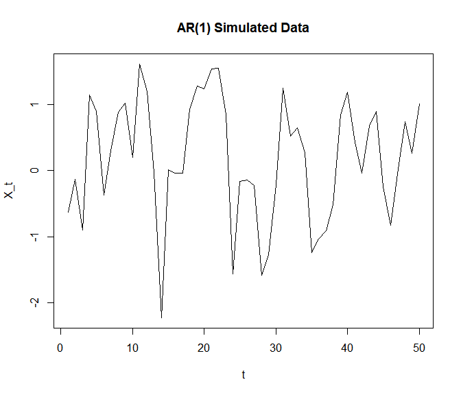

```r
set.seed(1)
n <- 50
phi <- 0.5
theta <- c(0.5, 0.25)
wn <- rnorm(n)

ar <- gen_arma(n, wn, ar_coefs = phi, ma_coefs = NULL)
ma <- gen_arma(n, wn, ar_coefs = NULL, ma_coefs = theta)
arma <- gen_arma(n, wn, ar_coefs = phi, ma_coefs = theta)

plot.ts(ar$data, main = "AR(1) Simulated Data", ylab = "X_t", xlab = "t")
```

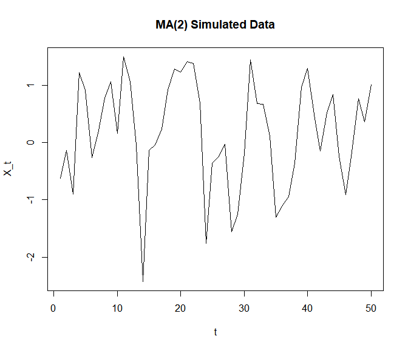

```r
plot.ts(ma$data, main = "MA(2) Simulated Data", ylab = "X_t", xlab = "t")
```

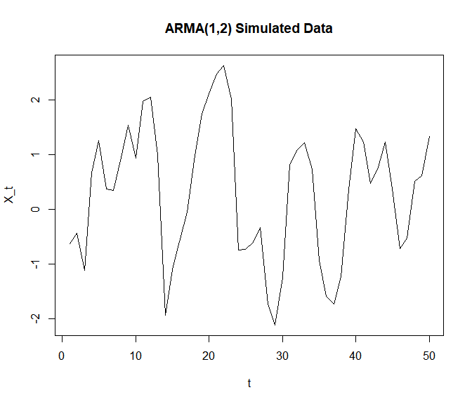

```r
plot.ts(arma$data, main = "ARMA(1,2) Simulated Data", ylab = "X_t", xlab = "t")
```

## Converting ARMA Model to Infinite-order MA Model

```r
converted_arma <- arma_to_ma(arma, max_lag = 10)
```

## Checking if Model is Causal

```r
is_causal(arma)
```

```
#> [1] TRUE
```

## Calculating Theoretical and Sample ACVFs and ACFs

```r
# For ARMA
arma_t_acvf <- get_theoretical_acvf(arma, sigma = 1, max_lag = 20)
arma_t_acf <- get_theoretical_acf(arma, sigma = 1, max_lag = 20)
arma_s_acvf <- get_sample_acvf(arma, max_lag = 20)
arma_s_acf <- get_sample_acf(arma, max_lag = 20)

# For AR
ar_t_acvf <- get_theoretical_acvf(ar, sigma = 1, max_lag = 20)
ar_t_acf <- get_theoretical_acf(ar, sigma = 1, max_lag = 20)
ar_s_acvf <- get_sample_acvf(ar, max_lag = 20)
ar_s_acf <- get_sample_acf(ar, max_lag = 20)

# For MA
ma_t_acvf <- get_theoretical_acvf(ma, sigma = 1, max_lag = 20)
ma_t_acf <- get_theoretical_acf(ma, sigma = 1, max_lag = 20)
ma_s_acvf <- get_sample_acvf(ma, max_lag = 20)
ma_s_acf <- get_sample_acf(ma, max_lag = 20)
```

## Plotting Theoretical ACVF and ACF

Here we visualize the sample and theoretical ACF and ACVF for each model.

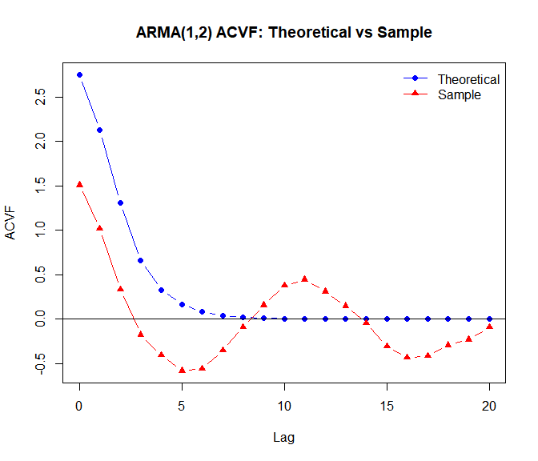

```r
# function to compare plots
plot_compare <- function(theoretical, sample, main, ylab) {
  lags <- 0:(length(theoretical) - 1)
  plot(lags, theoretical, type = "b", col = "blue", pch = 19,
       main = main, xlab = "Lag", ylab = ylab,
       ylim = range(c(theoretical, sample), na.rm = TRUE))
  lines(lags, sample, type = "b", col = "red", pch = 17)
  abline(h = 0)
  legend("topright", legend = c("Theoretical", "Sample"),
         col = c("blue", "red"), pch = c(19, 17), lty = 1, bty = "n")
}

# ARMA(1,2) plots
plot_compare(arma_t_acvf, arma_s_acvf,
             main = "ARMA(1,2) ACVF: Theoretical vs Sample",
             ylab = "ACVF")
```

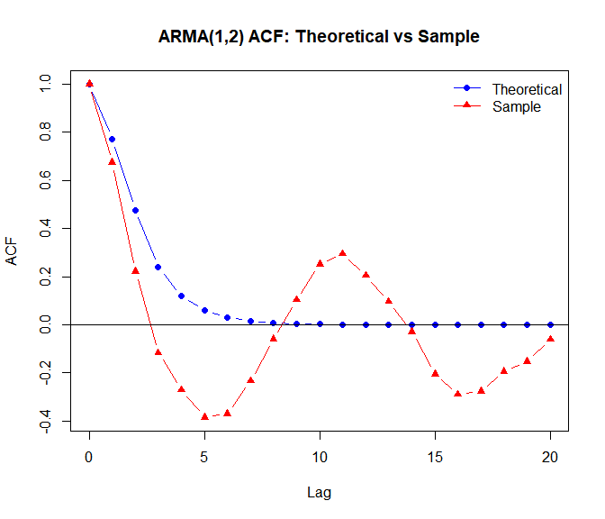

```r
plot_compare(arma_t_acf, arma_s_acf,
             main = "ARMA(1,2) ACF: Theoretical vs Sample",
             ylab = "ACF")
```

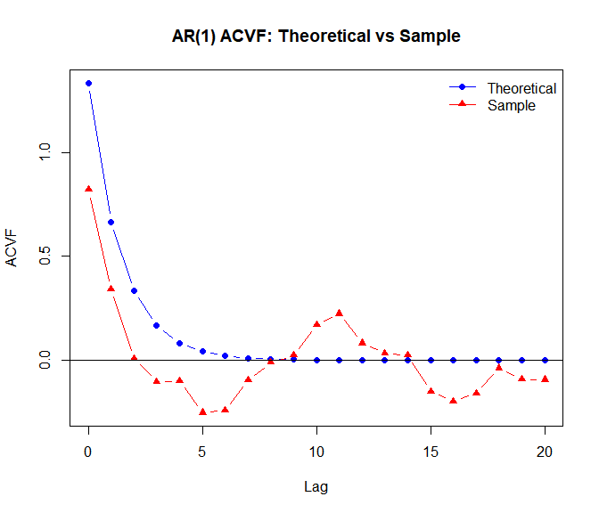

```r
# AR(1) plots
plot_compare(ar_t_acvf, ar_s_acvf,
             main = "AR(1) ACVF: Theoretical vs Sample",
             ylab = "ACVF")
```

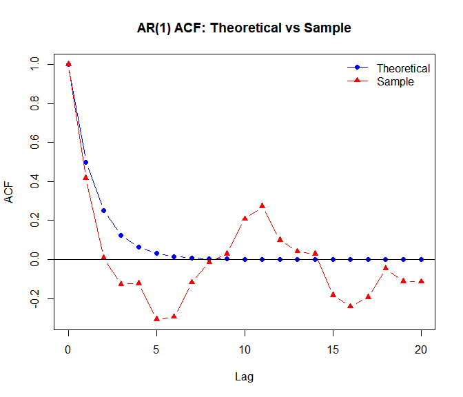

```r
plot_compare(ar_t_acf, ar_s_acf,
             main = "AR(1) ACF: Theoretical vs Sample",
             ylab = "ACF")
```

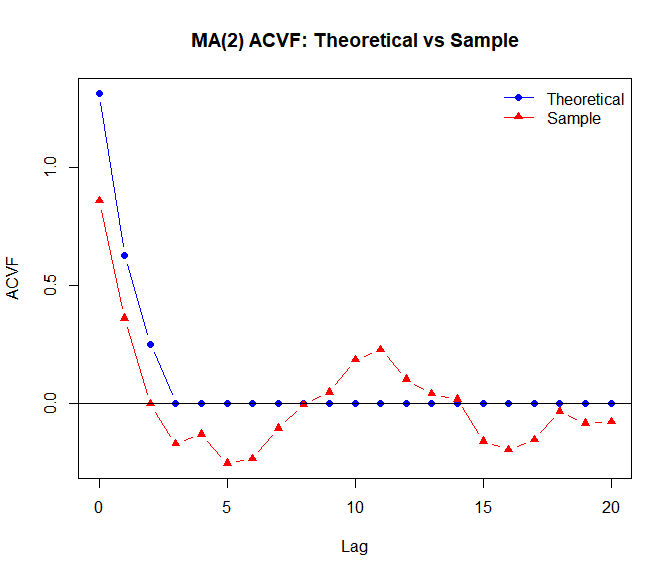

```r
# MA(2) plots
plot_compare(ma_t_acvf, ma_s_acvf,
             main = "MA(2) ACVF: Theoretical vs Sample",
             ylab = "ACVF")
```

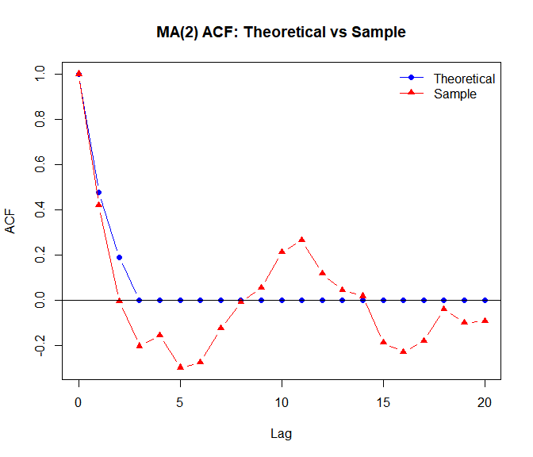

```r
plot_compare(ma_t_acf, ma_s_acf,
             main = "MA(2) ACF: Theoretical vs Sample",
             ylab = "ACF")
```

## Model Comparisons

We can see the following defining characteristics among the example models:

- The theoretical MA(2) ACVF and ACF go to zero after lag 2, as expected for MA(q) processes.
- The theoretical AR(1) and ARMA(1, 2) ACVF and ACF converge to zero as lag goes to infinity, also expected for AR(p) and ARMA(p, q) processes.
- Sample ACVF and ACF follow their theoretical counterparts, though offset, and exhibit sinusoidal behavior for large lags, reflecting the noise found in samples.

## Generative AI Declaration

Generative AI was used to assist in the writing, testing, and documentation of some functions and test cases.

# Bibliography

Brockwell, P. J., and R. A. Davis. 2016. *Introduction to Time Series and Forecasting*. Springer Texts in Statistics. Springer International Publishing. https://books.google.ca/books?id=P3fhDAAAQBAJ.

Chang, Winston, Joe Cheng, JJ Allaire, Carson Sievert, Barret Schloerke, Yihui Xie, Jeff Allen, Jonathan McPherson, Alan Dipert, and Barbara Borges. 2024. *Shiny: Web Application Framework for r*. https://CRAN.R-project.org/package=shiny.

McLeod, Ian. 2018. “Derivation of the Theoretical Autocovariance Function of Autoregressive–Moving Average Time Series.” *Journal of the Royal Statistical Society Series C: Applied Statistics* 24 (2): 255–56. https://doi.org/10.2307/2346573.

Wickham, Hadley. 2011. “Testthat: Get Started with Testing.” *The R Journal* 3: 5–10. https://journal.r-project.org/archive/2011-1/RJournal_2011-1_Wickham.pdf.

Wickham, Hadley, Peter Danenberg, Gabor Csardi, and Manuel Eugster. 2024. *Roxygen2: In-Line Documentation for r*. https://CRAN.R-project.org/package=roxygen2.